# Educational Big Data

2025-04-21

0.匯入資料

```r
library(readr)
user_data <- read_csv("~/Desktop/IT/統計/Edu/user_data.csv")
user_data$user_sn <- as.factor(user_data$user_sn)
dp001_prac <- read_csv("~/Desktop/IT/統計/Edu/dp001_prac.csv")
dp001_exam <- read_csv("~/Desktop/IT/統計/Edu/dp001_exam.csv")
dp001_review <- read_csv("~/Desktop/IT/統計/Edu/dp001_review.csv")
dp001_review_plus <- read_csv("~/Desktop/IT/統計/Edu/dp001_review_plus.csv")
```

第一步：將user_data、dp001_prac和dp001_review按user_sn合併

```r
data_raw <- merge(user_data, dp001_prac, by = "user_sn", all = TRUE)
data_raw <- merge(data_raw, dp001_review, by = "user_sn", all = TRUE)
```

第二步：將data_raw與dp001_review_plus和dp001_exam按review_sn合併

```r
data1 <- merge(data_raw, dp001_review_plus, by = "review_sn", all = TRUE)
data1 <- merge(data1, dp001_exam, by = "review_sn", all = TRUE)
str(data1)
```

```
## 'data.frame':    4933630 obs. of  37 variables:
##  $ review_sn         : num  97932045 97932045 97932045 97932045 97932045 ...
##  $ user_sn           : Factor w/ 95 levels "2697","4381",..: 65 65 65 65 65 65 65 65 65 65 ...
##  $ organization_id   : num  1808 1808 1808 1808 1808 ...
##  $ grade             : num  5 5 5 5 5 5 5 5 5 5 ...
##  $ class             : num  3 3 3 3 3 3 3 3 3 3 ...
##  $ seat              : num  13 13 13 13 13 13 13 13 13 13 ...
##  $ chinese_score     : num  80 80 80 80 80 80 80 80 80 80 ...
##  $ math_score        : num  40 40 40 40 40 40 40 40 40 40 ...
##  $ english_score     : num  89 89 89 89 89 89 89 89 89 89 ...
##  $ prac_sn           : num  53238695 53238695 53238695 53238695 53238695 ...
##  $ date              : POSIXct, format: "2024-04-23 08:24:48" "2024-04-23 08:24:48" ...
##  $ during_time       : num  5 5 5 5 5 5 4 4 4 4 ...
##  $ score_rate        : num  100 100 100 100 100 100 100 100 100 100 ...
##  $ binary_res.x      : chr  "1@XX@1@XX@" "1@XX@1@XX@" "1@XX@1@XX@" "1@XX@1@XX@" ...
```

[output cut: 23 more lines]

```r
colSums(is.na(data1))
```

```
##          review_sn            user_sn    organization_id              grade
##                514                  0                  0                  0
##              class               seat      chinese_score         math_score
##                  0                  0                  0                  0
##      english_score            prac_sn               date        during_time
##                  0                 11                 11                 11
##         score_rate       binary_res.x     items_ans_time   indicator_name.x
##                 11                 11                 11                 11
##     subject_name.x   indicator_name.y     subject_name.y         video_name
##                 11                514                514                514
##          video_len    start_timestamp         start_time      end_timestamp
##                514                514                514                514
##           end_time        finish_rate     review_plus_sn          view_time
##                514                514                514                514
##        view_action          timestamp              turbo            exam_sn
##                514                514            4747769             855784
##        question_sn question_timestamp       binary_res.y        finish_time
##             855784             855784             855784             855784
##           ans_time
##             855784
```

```r
num_user <- length(unique(data1$user_sn))
num_user
```

```
## [1] 95
```

```r
library(dplyr)
data1 <- data1 %>% distinct()
data1 <- na.omit(data1)
str(data1) ###資料數剩下149743筆
```

```
## 'data.frame':    149743 obs. of  37 variables:
##  $ review_sn         : num  9.8e+07 9.8e+07 9.8e+07 9.8e+07 9.8e+07 ...
##  $ user_sn           : Factor w/ 95 levels "2697","4381",..: 14 14 14 14 14 14 14 14 14 14 ...
##  $ organization_id   : num  1808 1808 1808 1808 1808 ...
##  $ grade             : num  5 5 5 5 5 5 5 5 5 5 ...
##  $ class             : num  3 3 3 3 3 3 3 3 3 3 ...
##  $ seat              : num  1 1 1 1 1 1 1 1 1 1 ...
##  $ chinese_score     : num  70 70 70 70 70 70 70 70 70 70 ...
##  $ math_score        : num  60 60 60 60 60 60 60 60 60 60 ...
##  $ english_score     : num  83 83 83 83 83 83 83 83 83 83 ...
##  $ prac_sn           : num  51314847 52270258 50375717 51227117 50374971 ...
##  $ date              : POSIXct, format: "2024-02-29 07:48:16" "2024-03-26 07:38:51" ...
##  $ during_time       : num  80 4 5 8 6 20 24 20 318 118 ...
##  $ score_rate        : num  0 100 50 50 100 100 100 0 100 0 ...
##  $ binary_res.x      : chr  "0@XX@0@XX@" "1@XX@1@XX@" "1@XX@0@XX@" "1@XX@0@XX@" ...
```

[output cut: 25 more lines]

轉換資料型態

```r
data1$user_sn <- as.factor(data1$user_sn)
data1$review_sn <- as.factor(data1$review_sn)
data1$grade <- as.factor(data1$grade)
data1$class <- as.factor(data1$class)
data1$seat <- as.factor(data1$seat)
data1$prac_sn <- as.factor(data1$prac_sn)
data1$indicator_name.x <- as.factor(data1$indicator_name.x)
data1$subject_name.y <- as.factor(data1$subject_name.y)
data1$video_name <- as.factor(data1$video_name)
data1$review_plus_sn <- as.factor(data1$review_plus_sn)
data1$exam_sn <- as.factor(data1$exam_sn)
data1$question_sn <- as.factor(data1$question_sn)
data1$view_action <- as.factor(data1$view_action)
data1$organization_id <- as.factor(data1$organization_id)
str(data1)
```

```
## 'data.frame':    149743 obs. of  37 variables:
##  $ review_sn         : Factor w/ 557 levels "97967614","98080875",..: 1 1 1 1 1 1 1 1 1 1 ...
##  $ user_sn           : Factor w/ 95 levels "2697","4381",..: 14 14 14 14 14 14 14 14 14 14 ...
##  $ organization_id   : Factor w/ 3 levels "338","1808","2486": 2 2 2 2 2 2 2 2 2 2 ...
##  $ grade             : Factor w/ 1 level "5": 1 1 1 1 1 1 1 1 1 1 ...
##  $ class             : Factor w/ 2 levels "1","3": 2 2 2 2 2 2 2 2 2 2 ...
##  $ seat              : Factor w/ 25 levels "1","2","3","4",..: 1 1 1 1 1 1 1 1 1 1 ...
##  $ chinese_score     : num  70 70 70 70 70 70 70 70 70 70 ...
##  $ math_score        : num  60 60 60 60 60 60 60 60 60 60 ...
##  $ english_score     : num  83 83 83 83 83 83 83 83 83 83 ...
##  $ prac_sn           : Factor w/ 1525 levels "49606796","49606810",..: 345 804 128 329 124 1263 1285 1195 209 598 ...
##  $ date              : POSIXct, format: "2024-02-29 07:48:16" "2024-03-26 07:38:51" ...
##  $ during_time       : num  80 4 5 8 6 20 24 20 318 118 ...
##  $ score_rate        : num  0 100 50 50 100 100 100 0 100 0 ...
##  $ binary_res.x      : chr  "0@XX@0@XX@" "1@XX@1@XX@" "1@XX@0@XX@" "1@XX@0@XX@" ...
```

[output cut: 25 more lines]

用finish_rate分為三組 Create a new variable “finish_level” based on the Finish_rate values

```r
data1$finish_level <- cut(data1$finish_rate, breaks = c(0, 50, 90, 100),
                          labels = c("low", "median", "high"))
```

Summarize the counts of each finish_level category

```r
table(data1$finish_level)
```

```
##
##    low median   high
##   4194  22574 122403
```

使用 cut() 函數將 Finish_rate 分成三個區間

```r
data1$finish_level2 <- cut(data1$finish_rate, breaks = c(0, 23, 73, 100),
                          labels = c("low", "median", "high"))
```

統計每個分類的筆數

```r
table(data1$finish_level2)
```

```
##
##    low median   high
##    381  16140 132650
```

使用 cut() 函數將 Finish_rate 分成三個區間

```r
data1$finish_level3 <- cut(data1$finish_rate, breaks = c(0, 50, 99, 100),
                           labels = c("low", "median", "high"))
```

統計每個分類的筆數

```r
table(data1$finish_level3)
```

```
##
##    low median   high
##   4194  24519 120458
```

```r
str(data1$subject_name.x)
```

```
##  chr [1:149743] "數學108" "自然108" "自然108" "數學108" "自然108" "防災" ...
```

```r
str(data1)
```

```
## 'data.frame':    149743 obs. of  40 variables:
##  $ review_sn         : Factor w/ 557 levels "97967614","98080875",..: 1 1 1 1 1 1 1 1 1 1 ...
##  $ user_sn           : Factor w/ 95 levels "2697","4381",..: 14 14 14 14 14 14 14 14 14 14 ...
##  $ organization_id   : Factor w/ 3 levels "338","1808","2486": 2 2 2 2 2 2 2 2 2 2 ...
##  $ grade             : Factor w/ 1 level "5": 1 1 1 1 1 1 1 1 1 1 ...
##  $ class             : Factor w/ 2 levels "1","3": 2 2 2 2 2 2 2 2 2 2 ...
##  $ seat              : Factor w/ 25 levels "1","2","3","4",..: 1 1 1 1 1 1 1 1 1 1 ...
##  $ chinese_score     : num  70 70 70 70 70 70 70 70 70 70 ...
##  $ math_score        : num  60 60 60 60 60 60 60 60 60 60 ...
##  $ english_score     : num  83 83 83 83 83 83 83 83 83 83 ...
##  $ prac_sn           : Factor w/ 1525 levels "49606796","49606810",..: 345 804 128 329 124 1263 1285 1195 209 598 ...
##  $ date              : POSIXct, format: "2024-02-29 07:48:16" "2024-03-26 07:38:51" ...
##  $ during_time       : num  80 4 5 8 6 20 24 20 318 118 ...
##  $ score_rate        : num  0 100 50 50 100 100 100 0 100 0 ...
##  $ binary_res.x      : chr  "0@XX@0@XX@" "1@XX@1@XX@" "1@XX@0@XX@" "1@XX@0@XX@" ...
```

[output cut: 28 more lines]

檢查年級類別

```r
levels(data1$grade)
```

```
## [1] "5"
```

```r
levels(data1$organization_id)
```

```
## [1] "338"  "1808" "2486"
```

計算每個學校的總人數（使用 unique user_sn）

```r
library(dplyr)
school_distribution <- data1 %>%
  select(user_sn, organization_id) %>%
  unique() %>%
  group_by(organization_id) %>%
  summarise(
    student_count = n(),
    percentage = round(n() / length(unique(data1$organization_id)) * 100, 1)
  )

print(school_distribution)
```

```
## # A tibble: 3 × 3
##   organization_id student_count percentage
##   <fct>                   <int>      <dbl>
## 1 338                        21        700
## 2 1808                       12        400
## 3 2486                       12        400
```

```r
total_students <- sum(school_distribution$student_count)
print(paste("總學生人數：", total_students))
```

```
## [1] "總學生人數： 45"
```

計算不重複的影片數量（使用video_name）

```r
unique_videos <- length(unique(data1$video_name))
unique_videos
```

```
## [1] 91
```

計算總觀看次數（使用review_sn）

```r
total_views <- length(unique(data1$review_sn))
total_views
```

```
## [1] 557
```

計算每部影片的觀看次數

```r
views_per_video <- table(data1$video_name[!duplicated(data1$review_sn)])
views_per_video
```

```
##
##                    INb-Ⅲ-6-01                    INc-Ⅲ-1-01
##                             2                             1
##                    INc-Ⅲ-1-03                   INc-Ⅲ-14-01
##                             1                             4
##                   INc-Ⅲ-14-03                   INc-Ⅲ-14-04
##                             1                             6
##                   INc-Ⅲ-14-05                   INc-Ⅲ-14-06
##                             4                             5
##                   INc-Ⅲ-14-07                   INc-Ⅲ-15-01
##                             4                             6
##                    INc-Ⅲ-5-01                    INc-Ⅲ-8-01
##                             1                             3
##                    INd-Ⅲ-1-01                    INd-Ⅲ-1-02
##                             3                             2
##                   INd-Ⅲ-13-01                   INe-Ⅲ-12-01
##                             6                             3
##                   INe-Ⅲ-12-02                   INe-Ⅲ-12-04
##                             2                             2
##                    INe-Ⅲ-2-01                    INe-Ⅲ-2-02
##                             5                             3
##                    INe-Ⅲ-2-03                    INe-Ⅲ-2-04
##                             4                             3
##                    INe-Ⅲ-2-05                    INe-Ⅲ-3-01
##                             5                             4
##                    INe-Ⅲ-3-02              video:4-n-01-S01
##                             4                            10
##              video:4-n-01-S03              video:4-n-13-S05
##                            13                             1
##              video:4-n-15-S02              video:5-a-01-S01
##                            11                             2
##              video:5-a-01-S03              video:5-n-01-S04
##                             1                             2
##              video:5-n-01-S06              video:5-n-02-S03
##                             2                             2
##              video:5-n-03-S02              video:5-n-05-S05
##                             1                             3
##              video:5-n-06-S01              video:5-n-06-S02
##                             2                             2
##              video:5-n-06-S03              video:5-n-07-S02
```

[output cut: 38 more lines]

```
##                             5                             9
##              video:5-n-21-S01              video:5-n-21-S02
##                            10                            12
##              video:5-n-21-S03              video:5-n-21-S04
##                            11                             8
##              video:5-s-01-S02              video:5-s-02-S03
##                             1                             1
##              video:5-s-03-S03              video:5-s-04-S02
##                             3                             1
##              video:6-d-02-S03              video:6-d-02-S04
##                             9                            11
##                地震保命與求救                緊急避難包準備
##                             4                             4
## 體適能評估-肌力肌耐力運動處方
##                             1
```

計算平均每部影片觀看次數

```r
avg_views_per_video <- total_views / unique_videos

# 顯示結果
cat("影片總數：", unique_videos, "部\n")
```

```
## 影片總數： 91 部
```

```r
cat("總觀看次數：", total_views, "次\n")
```

```
## 總觀看次數： 557 次
```

```r
cat("平均每部影片觀看：", round(avg_views_per_video, 2), "次\n")
```

```
## 平均每部影片觀看： 6.12 次
```

顯示觀看次數分布的摘要統計

```r
summary_stats <- summary(as.numeric(views_per_video))
print("各影片觀看次數的分布概況：")
```

```
## [1] "各影片觀看次數的分布概況："
```

```r
print(summary_stats)
```

```
##    Min. 1st Qu.  Median    Mean 3rd Qu.    Max.
##   1.000   2.000   5.000   6.121  10.000  16.000
```

找出觀看次數最多和最少的影片

```r
most_viewed <- names(sort(views_per_video, decreasing = TRUE)[1])
least_viewed <- names(sort(views_per_video)[1])

cat("\n觀看次數最多的影片：", most_viewed, "（", max(views_per_video), "次）\n")
```

```
##
## 觀看次數最多的影片： video:5-n-08-S07 （ 16 次）
```

```r
cat("觀看次數最少的影片：", least_viewed, "（", min(views_per_video), "次）\n")
```

```
## 觀看次數最少的影片： INc-Ⅲ-1-01 （ 1 次）
```

了解影片操作行為## 計算不重複的影片操作數量（使用view_action）

```r
unique_actions <- length(unique(data1$view_action))
unique_actions
```

```
## [1] 3
```

計算每個動作的次數

```r
action_counts <- table(data1$view_action)
```

轉換成數據框以便繪圖

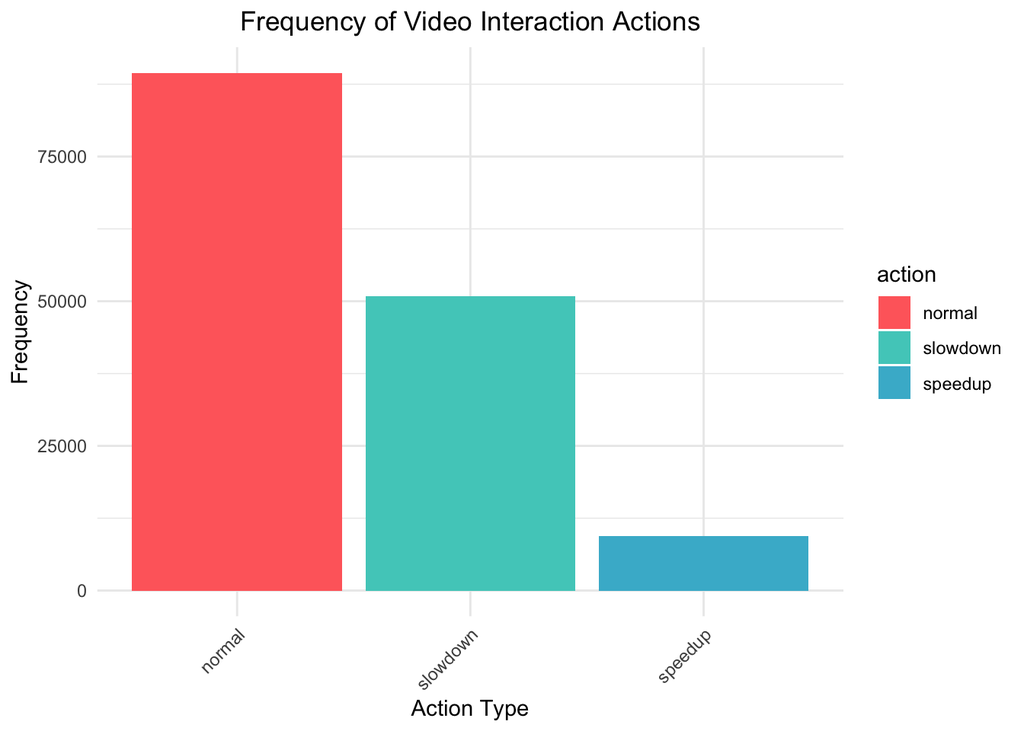

```r
action_df <- data.frame(
  action = names(action_counts),
  count = as.numeric(action_counts)
)

library(ggplot2)

custom_colors <- c(
  "#FF6B6B", "#4ECDC4", "#45B7D1", "#96CEB4", "#FFEEAD",
  "#D4A5A5", "#9B59B6", "#3498DB", "#E67E22", "#1ABC9C",
  "#F1C40F", "#E74C3C", "#2ECC71", "#34495E", "#95A5A6",
  "#16A085", "#8E44AD", "#2980B9", "#F39C12"
)

ggplot(action_df, aes(x = reorder(action, -count), y = count, fill = action)) +
  geom_bar(stat = "identity") +
  scale_fill_manual(values = custom_colors) +
  theme_minimal() +
  labs(
    title = "Frequency of Video Interaction Actions",
    x = "Action Type",
    y = "Frequency"
  ) +
  theme(
    axis.text.x = element_text(angle = 45, hjust = 1),
    plot.title = element_text(hjust = 0.5)
  )
```

```r
print(action_counts)
```

```
##
##   normal slowdown  speedup
##    89443    50896     9404
```

創建數據框並排序

```r
action_data <- data.frame(
  action = c("browse", "chkptend", "chkptstart", "continue", "dragleft", "dragright",
             "dragstart", "end", "fuscreenoff", "fuscreenon", "normal", "note",
             "paused", "play", "question", "review", "slowdown", "speedup"),
  count = c(224859, 426419, 426012, 54324, 162490, 55091,
            245691, 151362, 38177, 78971, 111780, 661,
            1387512, 1466717, 100, 28869, 56255, 17826)
)

action_sorted <- action_data[order(action_data$count, decreasing = TRUE), ]
```

找出最高和最低的幾個值

```r
top_actions <- head(action_sorted, 3)
bottom_actions <- tail(action_sorted, 3)
```

計算中等範圍的行為數量

```r
mid_range_count <- sum(action_sorted$count < 250000 & action_sorted$count > 50000)
```

生成報告

```r
cat("影片互動行為分析摘要：\n\n")
```

```
## 影片互動行為分析摘要：
```

```r
cat("1. 最常見的行為：\n")
```

```
## 1. 最常見的行為：
```

```r
cat(sprintf("   - 播放(play)行為最多，共%s次\n", format(top_actions$count[1], big.mark=",")))
```

```
##    - 播放(play)行為最多，共1,466,717次
```

```r
cat(sprintf("   - 暫停(paused)次之，共%s次\n", format(top_actions$count[2], big.mark=",")))
```

```
##    - 暫停(paused)次之，共1,387,512次
```

```r
cat(sprintf("   - 檢核點相關行為緊隨其後，檢核點作答結束(chkptend)與開始(chkptstart)次數相近，分別為%s次與%s次\n\n",
            format(426419, big.mark=","), format(426012, big.mark=",")))
```

```
##    - 檢核點相關行為緊隨其後，檢核點作答結束(chkptend)與開始(chkptstart)次數相近，分別為426,419次與426,012次
```

```r
cat("2. 中等頻率行為：\n")
```

```
## 2. 中等頻率行為：
```

```r
cat(sprintf("   - 共有%d種行為的發生次數介於50,000到250,000次之間\n", mid_range_count))
```

```
##    - 共有9種行為的發生次數介於50,000到250,000次之間
```

```r
cat("   - 包括拖曳開始(dragstart)、瀏覽(browse)、向左拖曳(dragleft)等行為\n\n")
```

```
##    - 包括拖曳開始(dragstart)、瀏覽(browse)、向左拖曳(dragleft)等行為
```

```r
cat("3. 最少見的行為：\n")
```

```
## 3. 最少見的行為：
```

```r
for(i in nrow(bottom_actions):1) {
  cat(sprintf("   - %s：%s次\n",
              bottom_actions$action[i],
              format(bottom_actions$count[i], big.mark=",")))
}
```

```
##    - question：100次
##    - note：661次
##    - speedup：17,826次
```

```r
str(data1)
```

```
## 'data.frame':    149743 obs. of  40 variables:
##  $ review_sn         : Factor w/ 557 levels "97967614","98080875",..: 1 1 1 1 1 1 1 1 1 1 ...
##  $ user_sn           : Factor w/ 95 levels "2697","4381",..: 14 14 14 14 14 14 14 14 14 14 ...
##  $ organization_id   : Factor w/ 3 levels "338","1808","2486": 2 2 2 2 2 2 2 2 2 2 ...
##  $ grade             : Factor w/ 1 level "5": 1 1 1 1 1 1 1 1 1 1 ...
##  $ class             : Factor w/ 2 levels "1","3": 2 2 2 2 2 2 2 2 2 2 ...
##  $ seat              : Factor w/ 25 levels "1","2","3","4",..: 1 1 1 1 1 1 1 1 1 1 ...
##  $ chinese_score     : num  70 70 70 70 70 70 70 70 70 70 ...
##  $ math_score        : num  60 60 60 60 60 60 60 60 60 60 ...
##  $ english_score     : num  83 83 83 83 83 83 83 83 83 83 ...
##  $ prac_sn           : Factor w/ 1525 levels "49606796","49606810",..: 345 804 128 329 124 1263 1285 1195 209 598 ...
##  $ date              : POSIXct, format: "2024-02-29 07:48:16" "2024-03-26 07:38:51" ...
##  $ during_time       : num  80 4 5 8 6 20 24 20 318 118 ...
##  $ score_rate        : num  0 100 50 50 100 100 100 0 100 0 ...
##  $ binary_res.x      : chr  "0@XX@0@XX@" "1@XX@1@XX@" "1@XX@0@XX@" "1@XX@0@XX@" ...
```

[output cut: 28 more lines]

影片開始與結束時間 載入需要的套件

```r
library(ggplot2)
library(dplyr)
library(lubridate)
```

1. 數據處理：計算每日觀看開始次數

```r
daily_views <- data1 %>%
  group_by(date = as.Date(start_time)) %>%
  summarise(count = n())
```

2. 繪製折線圖

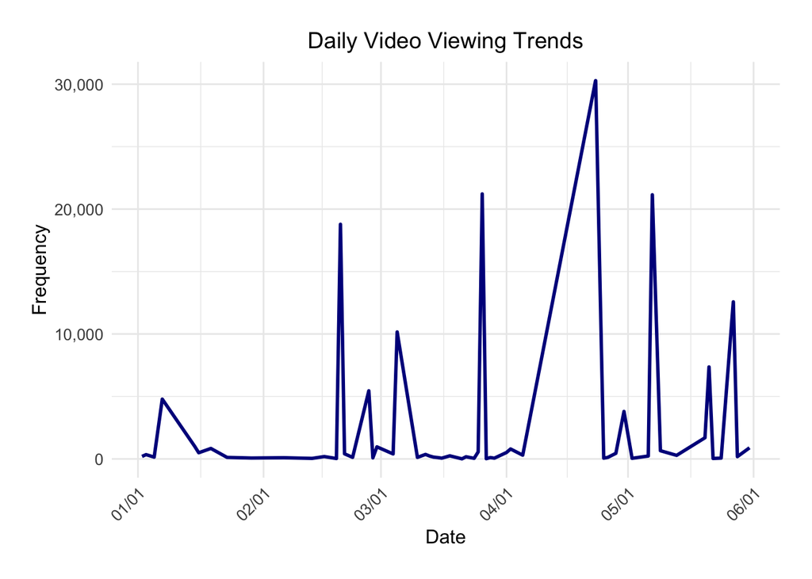

```r
ggplot(daily_views, aes(x = date, y = count)) +
  geom_line(color = "darkblue", size = 1) +  # 設定線條為紅色
  theme_minimal() +
  labs(
    title = "Daily Video Viewing Trends",
    x = "Date",
    y = "Frequency"
  ) +
  theme(
    axis.text.x = element_text(angle = 45, hjust = 1, size = 10),
    axis.text.y = element_text(size = 10),
    axis.title = element_text(size = 12),
    plot.title = element_text(hjust = 0.5, size = 14),
    plot.margin = margin(t = 20, r = 20, b = 20, l = 20)
  ) +
  scale_x_date(
    date_breaks = "1 month",
    date_labels = "%m/%d"
  ) +
  scale_y_continuous(
    labels = scales::comma
  )
```

3. 輸出一些基本統計資訊

```r
summary_stats <- daily_views %>%
  summarise(
    Total_Views = sum(count),
    Average_Daily_Views = mean(count),
    Highest_Daily_Views = max(count),
    Lowest_Daily_Views = min(count)
  )

print(summary_stats)
```

```
## # A tibble: 1 × 4
##   Total_Views Average_Daily_Views Highest_Daily_Views Lowest_Daily_Views
##         <int>               <dbl>               <int>              <int>
## 1      149743               2674.               30286                  7
```

影片科目# 檢查科目類別

```r
str(dp001_review)
```

```
## spc_tbl_ [3,997 × 11] (S3: spec_tbl_df/tbl_df/tbl/data.frame)
##  $ user_sn        : num [1:3997] 221236 221236 20034 20034 307570 ...
##  $ review_sn      : num [1:3997] 97932045 97932104 97967614 97968472 97978630 ...
##  $ indicator_name : chr [1:3997] "字音[三]/本音4" "字形[三]/同音字2" "測量力的工具和方法" "力的測量記錄與判讀" ...
##  $ subject_name   : chr [1:3997] "國語文108" "國語文108" "自然108" "自然108" ...
##  $ video_name     : chr [1:3997] "字音[三]/本音4" "字形[三]/同音字2" "INc-Ⅲ-1-01" "INc-Ⅲ-1-02" ...
##  $ video_len      : num [1:3997] 82.4 147.1 225.7 463.7 374.1 ...
##  $ start_timestamp: num [1:3997] 0 0 0 0 151 ...
##  $ start_time     : POSIXct[1:3997], format: "2024-01-02 07:38:34" "2024-01-02 07:40:22" ...
##  $ end_timestamp  : num [1:3997] 82.4 19.6 225.7 463.6 307.3 ...
##  $ end_time       : POSIXct[1:3997], format: "2024-01-02 07:40:03" "2024-01-02 07:40:46" ...
##  $ finish_rate    : num [1:3997] 100 13 100 100 82 100 58 24 100 100 ...
##  - attr(*, "spec")=
##   .. cols(
##   ..   user_sn = col_double(),
##   ..   review_sn = col_double(),
##   ..   indicator_name = col_character(),
##   ..   subject_name = col_character(),
##   ..   video_name = col_character(),
##   ..   video_len = col_double(),
##   ..   start_timestamp = col_double(),
##   ..   start_time = col_datetime(format = ""),
##   ..   end_timestamp = col_double(),
##   ..   end_time = col_datetime(format = ""),
##   ..   finish_rate = col_double()
##   .. )
##  - attr(*, "problems")=<externalptr>
```

```r
dp001_review$subject_name <- as.factor(dp001_review$subject_name)
levels(dp001_review$subject_name)
```

```
##  [1] "交通安全"     "健康與體育"   "國語文"       "國語文108"    "師資生國語"
##  [6] "數學"         "數學108"      "日文"         "演算法"       "環境教育議題"
## [11] "視覺藝術"     "自主學習"     "自然"         "自然108"      "英語108"
## [16] "表演藝術"     "防災"         "音樂"
```

```r
subject_counts <- table(dp001_review$subject_name)
subject_counts
```

```
##
##     交通安全   健康與體育       國語文    國語文108   師資生國語         數學
##            2            5          121           37            1         2307
##      數學108         日文       演算法 環境教育議題     視覺藝術     自主學習
##          718            4            4            1            1            1
##         自然      自然108      英語108     表演藝術         防災         音樂
##            2          636          102            1           52            2
```

建立資料框

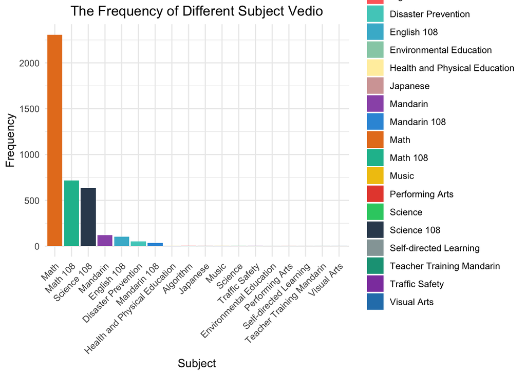

```r
subject_counts <- c(2, 5, 121, 37, 1, 2307, 718, 4, 4, 1, 1, 1, 2, 636, 102, 1, 52, 2)
subject_names <- c("Traffic Safety", "Health and Physical Education", "Mandarin", "Mandarin 108",
                   "Teacher Training Mandarin", "Math", "Math 108", "Japanese", "Algorithm",
                   "Environmental Education", "Visual Arts", "Self-directed Learning", "Science",
                   "Science 108", "English 108", "Performing Arts", "Disaster Prevention", "Music"
)

subject_df <- data.frame(
  action1 = subject_names,
  count1 = subject_counts
)

subject_colors <- c(
  "#FF6B6B", "#4ECDC4", "#45B7D1", "#96CEB4", "#FFEEAD",
  "#D4A5A5", "#9B59B6", "#3498DB", "#E67E22", "#1ABC9C",
  "#F1C40F", "#E74C3C", "#2ECC71", "#34495E", "#95A5A6",
  "#16A085", "#8E44AD", "#2980B9", "#FFC300"
)


library(ggplot2)
ggplot(subject_df, aes(x = reorder(action1, -count1), y = count1, fill = action1)) +
  geom_bar(stat = "identity") +
  scale_fill_manual(values = subject_colors) +
  theme_minimal() +
  labs(
    title = "The Frequency of Different Subject Vedio",
    x = "Subject",
    y = "Frequency"
  ) +
  theme(
    axis.text.x = element_text(angle = 45, hjust = 1),
    plot.title = element_text(hjust = 0.5)
  )
```

影片名稱

```r
dp001_review$video_name <- as.factor(dp001_review$video_name)
levels(dp001_review$video_name)
```

```
##   [1] "09-1-排序演算法-什麼是排序演算法"
##   [2] "1-SRL-1-S06"
##   [3] "10-1搜尋演算法-什麼是搜尋演算法"
##   [4] "10-2搜尋演算法-線性搜尋法"
##   [5] "10以內聽讀寫做、0的使用"
##   [6] "110-3c-01"
##   [7] "130-3a-01"
##   [8] "E-Ⅳ-1-1-06能了解ACappella的起源與演出形式(古典與現代)"
##   [9] "INa-Ⅲ-5-01"
##  [10] "INa-Ⅲ-7-01"
##  [11] "INb-Ⅲ-3-01"
##  [12] "INb-Ⅲ-3-02"
##  [13] "INb-Ⅲ-6-01"
##  [14] "INc-Ⅲ-1-01"
##  [15] "INc-Ⅲ-1-02"
```

[output cut: 259 more lines]

```r
video_counts <- table(dp001_review$video_name)
video_counts
```

```
##
##                                                                                09-1-排序演算法-什麼是排序演算法
##                                                                                                               2
##                                                                                                     1-SRL-1-S06
##                                                                                                               1
##                                                                                 10-1搜尋演算法-什麼是搜尋演算法
##                                                                                                               1
##                                                                                       10-2搜尋演算法-線性搜尋法
##                                                                                                               1
##                                                                                         10以內聽讀寫做、0的使用
##                                                                                                               1
##                                                                                                       110-3c-01
##                                                                                                               1
##                                                                                                       130-3a-01
##                                                                                                               1
##                                                           E-Ⅳ-1-1-06能了解ACappella的起源與演出形式(古典與現代)
##                                                                                                               1
##                                                                                                      INa-Ⅲ-5-01
##                                                                                                               1
##                                                                                                      INa-Ⅲ-7-01
##                                                                                                               8
##                                                                                                      INb-Ⅲ-3-01
##                                                                                                               1
##                                                                                                      INb-Ⅲ-3-02
##                                                                                                               2
##                                                                                                      INb-Ⅲ-6-01
##                                                                                                              17
##                                                                                                      INc-Ⅲ-1-01
##                                                                                                               5
##                                                                                                      INc-Ⅲ-1-02
##                                                                                                              13
##                                                                                                      INc-Ⅲ-1-03
##                                                                                                               3
##                                                                                                     INc-Ⅲ-14-01
##                                                                                                              34
##                                                                                                     INc-Ⅲ-14-03
##                                                                                                              30
##                                                                                                     INc-Ⅲ-14-04
##                                                                                                              23
##                                                                                                     INc-Ⅲ-14-05
```

[output cut: 494 more lines]

```
##                                                                                                               2
##                                                                    食物-Whatdoeshe/shewant?He/Shewantssomesoup.
##                                                                                                               3
##                                         食物-Whatdoyouwant?Iwanta/anapple/banana/orange/hamburger/sandwich/egg.
##                                                                                                               4
##                                                                       食物-Would you like some rice for dinner?
##                                                                                                               2
##                                                                                      食物-Wouldyoulikesomefood?
##                                                                                                               4
##                                                                                   體適能評估-肌力肌耐力運動處方
##                                                                                                               4
##                                                                                                        魔神封印
##                                                                                                               1
##                                                                                               魔神封印-思考教室
##                                                                                                               1
```

用不同影片完成率的低中高50,99來看學生的數學成績是否有顯著差異？ Filter the data for ‘math’ and ‘數學108’ in subject_name.x

```r
filtered_data <- data1[data1$subject_name.x %in% c('數學', '數學108'), ]
```

Check the results

```r
str(filtered_data)
```

```
## 'data.frame':    59791 obs. of  40 variables:
##  $ review_sn         : Factor w/ 557 levels "97967614","98080875",..: 1 1 1 1 1 1 1 1 1 1 ...
##  $ user_sn           : Factor w/ 95 levels "2697","4381",..: 14 14 14 14 14 14 14 14 14 14 ...
##  $ organization_id   : Factor w/ 3 levels "338","1808","2486": 2 2 2 2 2 2 2 2 2 2 ...
##  $ grade             : Factor w/ 1 level "5": 1 1 1 1 1 1 1 1 1 1 ...
##  $ class             : Factor w/ 2 levels "1","3": 2 2 2 2 2 2 2 2 2 2 ...
##  $ seat              : Factor w/ 25 levels "1","2","3","4",..: 1 1 1 1 1 1 1 1 1 1 ...
##  $ chinese_score     : num  70 70 70 70 70 70 70 70 70 70 ...
##  $ math_score        : num  60 60 60 60 60 60 60 60 60 60 ...
##  $ english_score     : num  83 83 83 83 83 83 83 83 83 83 ...
##  $ prac_sn           : Factor w/ 1525 levels "49606796","49606810",..: 345 329 1195 209 765 611 263 222 328 799 ...
##  $ date              : POSIXct, format: "2024-02-29 07:48:16" "2024-02-25 20:50:45" ...
##  $ during_time       : num  80 8 20 318 37 23 107 24 12 87 ...
##  $ score_rate        : num  0 50 0 100 100 50 0 0 0 0 ...
##  $ binary_res.x      : chr  "0@XX@0@XX@" "1@XX@0@XX@" "0@XX@0@XX@" "1@XX@1@XX@" ...
```

[output cut: 28 more lines]

```r
head(filtered_data)
```

```
##      review_sn user_sn organization_id grade class seat chinese_score
## 1012  97967614   20034            1808     5     3    1            70
## 1054  97967614   20034            1808     5     3    1            70
## 1079  97967614   20034            1808     5     3    1            70
## 1084  97967614   20034            1808     5     3    1            70
## 1096  97967614   20034            1808     5     3    1            70
## 1100  97967614   20034            1808     5     3    1            70
##      math_score english_score  prac_sn                date during_time
## 1012         60            83 51314847 2024-02-29 07:48:16          80
## 1054         60            83 51227117 2024-02-25 20:50:45           8
## 1079         60            83 53792866 2024-05-06 11:15:28          20
## 1084         60            83 51057996 2024-02-20 07:44:22         318
## 1096         60            83 51960338 2024-03-18 08:49:27          37
## 1100         60            83 51624505 2024-03-08 10:38:30          23
##      score_rate binary_res.x                       items_ans_time
```

[output cut: 48 more lines]

```r
INDAOV <- filtered_data[ ,c('user_sn','subject_name.x','finish_level3','math_score')]
str(INDAOV)
```

```
## 'data.frame':    59791 obs. of  4 variables:
##  $ user_sn       : Factor w/ 95 levels "2697","4381",..: 14 14 14 14 14 14 14 14 14 14 ...
##  $ subject_name.x: chr  "數學108" "數學108" "數學108" "數學108" ...
##  $ finish_level3 : Factor w/ 3 levels "low","median",..: 3 3 3 3 3 3 3 3 3 3 ...
##  $ math_score    : num  60 60 60 60 60 60 60 60 60 60 ...
```

```r
summary(INDAOV)
```

```
##     user_sn      subject_name.x     finish_level3    math_score
##  313378 : 9800   Length:59791       low   : 1816   Min.   :20.00
##  313897 : 9584   Class :character   median: 5835   1st Qu.:40.00
##  50836  : 4104   Mode  :character   high  :51982   Median :52.00
##  201286 : 3987                      NA's  :  158   Mean   :52.62
##  11312  : 3648                                     3rd Qu.:64.00
##  255091 : 3384                                     Max.   :88.00
##  (Other):25284
```

```r
firstANOVA <- na.omit(INDAOV)
summary(firstANOVA)
```

```
##     user_sn      subject_name.x     finish_level3    math_score
##  313378 : 9800   Length:59633       low   : 1816   Min.   :20.00
##  313897 : 9520   Class :character   median: 5835   1st Qu.:40.00
##  50836  : 4104   Mode  :character   high  :51982   Median :52.00
##  201286 : 3969                                     Mean   :52.61
##  11312  : 3648                                     3rd Qu.:64.00
##  255091 : 3366                                     Max.   :88.00
##  (Other):25226
```

```r
str(firstANOVA)
```

```
## 'data.frame':    59633 obs. of  4 variables:
##  $ user_sn       : Factor w/ 95 levels "2697","4381",..: 14 14 14 14 14 14 14 14 14 14 ...
##  $ subject_name.x: chr  "數學108" "數學108" "數學108" "數學108" ...
##  $ finish_level3 : Factor w/ 3 levels "low","median",..: 3 3 3 3 3 3 3 3 3 3 ...
##  $ math_score    : num  60 60 60 60 60 60 60 60 60 60 ...
##  - attr(*, "na.action")= 'omit' Named int [1:158] 3378 3379 3380 3381 3382 3383 3384 3385 3386 3387 ...
##   ..- attr(*, "names")= chr [1:158] "235083" "235084" "235713" "235714" ...
```

```r
library(car)
leveneTest(math_score~finish_level3, data=firstANOVA)
```

```
## Levene's Test for Homogeneity of Variance (center = median)
##          Df F value    Pr(>F)
## group     2  2249.4 < 2.2e-16 ***
##       59630
## ---
## Signif. codes:  0 '***' 0.001 '**' 0.01 '*' 0.05 '.' 0.1 ' ' 1
```

```r
INDAOV.op <- aov(math_score ~finish_level3, data=firstANOVA )
summary(INDAOV.op)
```

```
##                  Df   Sum Sq Mean Sq F value Pr(>F)
## finish_level3     2    54979   27490   134.2 <2e-16 ***
## Residuals     59630 12215693     205
## ---
## Signif. codes:  0 '***' 0.001 '**' 0.01 '*' 0.05 '.' 0.1 ' ' 1
```

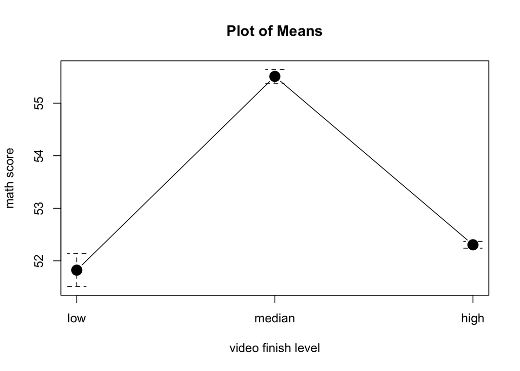

```r
library(car)
library(sandwich)
library(RcmdrMisc)
with(firstANOVA, plotMeans(math_score, finish_level3, main='Plot of Means',
                          xlab='video finish level', ylab='math score', error.bars='se'))
```

```r
library(agricolae)
TukeyHSD(INDAOV.op)
```

```
##   Tukey multiple comparisons of means
##     95% family-wise confidence level
##
## Fit: aov(formula = math_score ~ finish_level3, data = firstANOVA)
##
## $finish_level3
##                   diff       lwr       upr     p adj
## median-low   3.6860658  2.784682  4.587449 0.0000000
## high-low     0.4826252 -0.318181  1.283431 0.3343902
## high-median -3.2034406 -3.666578 -2.740303 0.0000000
```

```r
sch <- scheffe.test(INDAOV.op, 'finish_level3', group=F)
sch$comparison
```

```
##               Difference pvalue sig       LCL       UCL
## high - low     0.4826252 0.3688     -0.353753  1.319003
## high - median -3.2034406 0.0000 *** -3.687150 -2.719731
## low - median  -3.6860658 0.0000 *** -4.627489 -2.744643
```

dp002

```r
library(readr)
dp002_exam <- read_csv("~/Desktop/IT/統計/Edu/dp002_exam.csv")
str(dp002_exam)
```

```
## spc_tbl_ [45,824 × 8] (S3: spec_tbl_df/tbl_df/tbl/data.frame)
##  $ user_sn        : num [1:45824] 2697 2697 2697 2697 2697 ...
##  $ sn             : num [1:45824] 92987 92988 92989 92990 92991 ...
##  $ action_time    : POSIXct[1:45824], format: "2024-02-22 00:36:38" "2024-02-22 00:36:38" ...
##  $ object_type    : chr [1:45824] "英文閱讀" "英文閱讀" "英文閱讀" "英文閱讀" ...
##  $ result_duration: chr [1:45824] "PT7M51S" "PT7M51S" "PT7M51S" "PT7M51S" ...
##  $ result_success : logi [1:45824] FALSE FALSE FALSE TRUE FALSE TRUE ...
##  $ mission_id     : num [1:45824] -7.74e+18 -7.74e+18 -7.74e+18 -7.74e+18 -7.74e+18 ...
##  $ question_id    : num [1:45824] 8.19e+18 -1.16e+18 -3.22e+18 -4.38e+18 -3.22e+18 ...
##  - attr(*, "spec")=
##   .. cols(
##   ..   user_sn = col_double(),
##   ..   sn = col_double(),
##   ..   action_time = col_datetime(format = ""),
##   ..   object_type = col_character(),
##   ..   result_duration = col_character(),
##   ..   result_success = col_logical(),
##   ..   mission_id = col_double(),
##   ..   question_id = col_double()
##   .. )
##  - attr(*, "problems")=<externalptr>
```

```r
dp002_exam$object_type <- as.factor(dp002_exam$object_type)
levels(dp002_exam$object_type)
```

```
## [1] "中文閱讀" "英文閱讀"
```

```r
object_type_counts <- table(dp002_exam$object_type)
object_type_counts
```

```
##
## 中文閱讀 英文閱讀
##    20210    25614
```

```r
dp002_exam$user_sn <- as.factor(dp002_exam$user_sn)
dp002_exam$sn <- as.factor(dp002_exam$sn)
num_data2 <- length(unique(dp002_exam$user_sn))
num_data2
```

```
## [1] 57
```

Test把dp002和dp001合在一起

```r
data_R <- merge(dp002_exam, user_data, by = "user_sn", all = TRUE)
colSums(is.na(data_R))
```

```
##         user_sn              sn     action_time     object_type result_duration
##               0              38              38              38              38
##  result_success      mission_id     question_id organization_id           grade
##              38              38              38               0               0
##           class            seat   chinese_score      math_score   english_score
##               0               0               0               0               0
```

```r
num_user1 <- length(unique(data_R$user_sn))
num_user1
```

```
## [1] 95
```

dp003_word

```r
user_data$user_sn <- as.factor(user_data$user_sn)
dp003_word <- read_csv("~/Desktop/IT/統計/Edu/dp003_word.csv")
dp003_word$user_sn <- as.factor(dp003_word$user_sn)
```

dp003_math

```r
dp003_math <- read_csv("~/Desktop/IT/統計/Edu/dp003_math.csv")
str(dp003_math)
```

```
## spc_tbl_ [7,835 × 10] (S3: spec_tbl_df/tbl_df/tbl/data.frame)
##  $ user_sn           : num [1:7835] 2697 209884 6802 75997 183190 ...
##  $ sn                : num [1:7835] 6636 6637 6638 6639 6640 ...
##  $ game_grade        : num [1:7835] 4 1 1 3 1 1 3 1 1 3 ...
##  $ game_semester     : num [1:7835] 2 1 1 1 1 1 1 1 1 1 ...
##  $ unit_id           : num [1:7835] 5 1 6 4 6 1 3 2 6 4 ...
##  $ answer_problem_num: chr [1:7835] "142052012_011" "111011003_027" "111062002_029" "131042022_037" ...
##  $ is_correct        : num [1:7835] 1 1 0 1 1 0 1 1 1 1 ...
##  $ game_time         : num [1:7835] 80582 55997 2851 6676 12927 ...
##  $ last_modified     : num [1:7835] 1.72e+12 1.72e+12 1.72e+12 1.72e+12 1.72e+12 ...
##  $ unit_name         : chr [1:7835] "體積：立方公分" "10以內的數" "認識形狀" "認識圓和角" ...
##  - attr(*, "spec")=
##   .. cols(
##   ..   user_sn = col_double(),
##   ..   sn = col_double(),
##   ..   game_grade = col_double(),
##   ..   game_semester = col_double(),
##   ..   unit_id = col_double(),
##   ..   answer_problem_num = col_character(),
##   ..   is_correct = col_double(),
##   ..   game_time = col_double(),
##   ..   last_modified = col_double(),
##   ..   unit_name = col_character()
##   .. )
##  - attr(*, "problems")=<externalptr>
```

```r
dp003_math$user_sn <- as.factor(dp003_math$user_sn)
```

Test將dp001.2.3的user_sn合在一起，看共同學生有幾位

```r
data_t1 <- merge(user_data, dp002_exam, by = "user_sn", all = F)
data_t2 <- merge(data_t1, dp003_word, by = "user_sn", all = F)
data_t3 <- merge(data_t2, dp003_math, by = "user_sn", all = F)
data_t4 <- merge(user_data, dp003_math, by = "user_sn", all = F)
data_t5 <- merge(dp002_exam, dp003_word, by = "user_sn", all = F)

d5_user_num <- length(unique(data_t5$user_sn))
d5_user_num
```

```
## [1] 1
```

```r
d4_user_num <- length(unique(data_t4$user_sn))
d4_user_num
```

```
## [1] 24
```

```r
d12_user_num <- length(unique(data_t1$user_sn))
d12_user_num
```

```
## [1] 57
```

```r
d123w_user_num <- length(unique(data_t2$user_sn))
d123w_user_num
```

```
## [1] 1
```

```r
total_user_num <- length(unique(data_t3$user_sn))
total_user_num
```

```
## [1] 1
```